# Chapter 5

First, lets set the rownames to country names and explore the data and distributions

```r
#setting rownames to countries

df <- read.csv("human.csv")
row.names(df) <- df$Country
df <- df[,2:9]

#exploring the data and distributions
library(GGally)
```

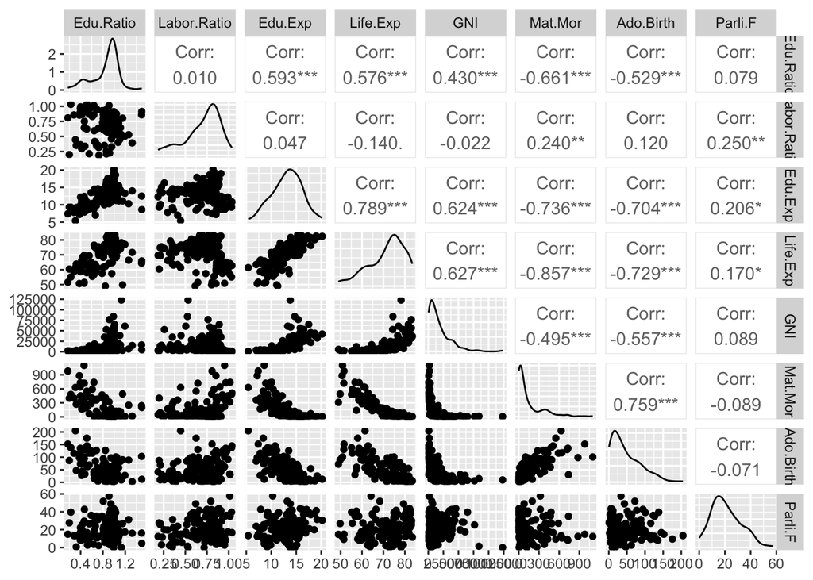

```r
ggpairs(df)
```

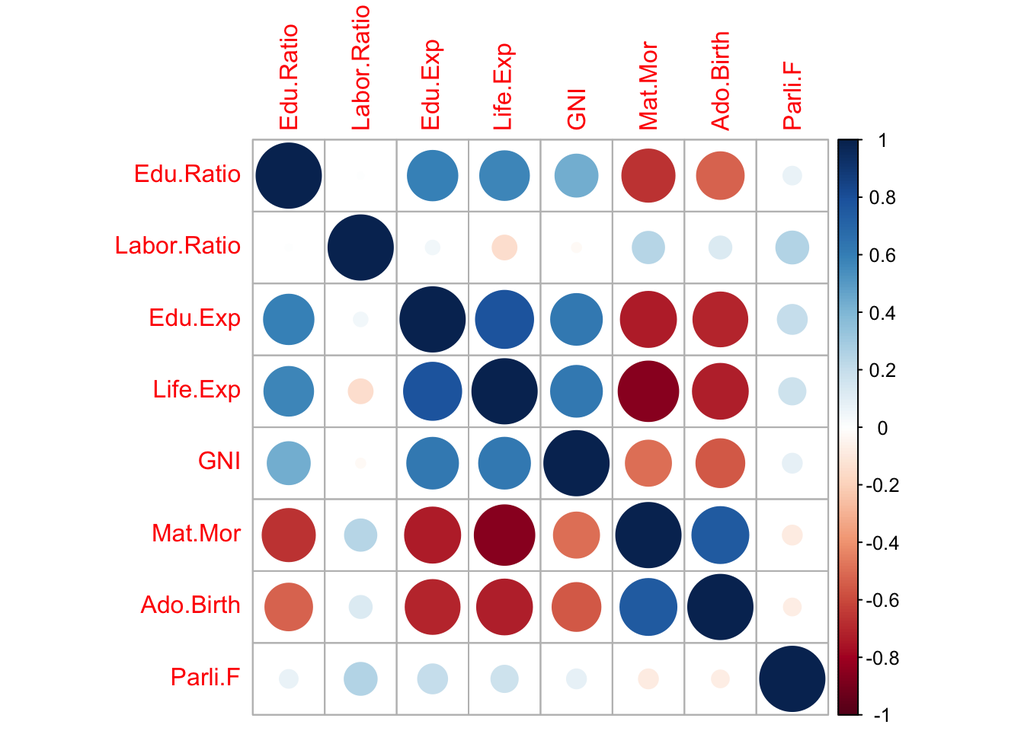

```r
library(corrplot)
cor(df) %>% corrplot()
```

Maternal mortality and life expectancy are highly correlated as well as adolecent birth rate and maternal mortality. Also some other very logical correlations like life expectancy and expected years of schooling. Distributions of ado.birth, mat.mort, GNI, and life.exp are highly skewed, other distribution look more symmetric/normal.

Performing principal component analysis. First, is the standardized data analysis.

```r
#standardization
df_s <- scale(df)

# print out summaries of the standardized variables
summary(df_s)
```

```
##    Edu.Ratio        Labor.Ratio         Edu.Exp           Life.Exp
##  Min.   :-2.8189   Min.   :-2.6247   Min.   :-2.7378   Min.   :-2.7188
##  1st Qu.:-0.5233   1st Qu.:-0.5484   1st Qu.:-0.6782   1st Qu.:-0.6425
##  Median : 0.3503   Median : 0.2316   Median : 0.1140   Median : 0.3056
##  Mean   : 0.0000   Mean   : 0.0000   Mean   : 0.0000   Mean   : 0.0000
##  3rd Qu.: 0.5958   3rd Qu.: 0.7350   3rd Qu.: 0.7126   3rd Qu.: 0.6717
##  Max.   : 2.6646   Max.   : 1.6632   Max.   : 2.4730   Max.   : 1.4218
##       GNI             Mat.Mor          Ado.Birth          Parli.F
##  Min.   :-0.9193   Min.   :-0.6992   Min.   :-1.1325   Min.   :-1.8203
##  1st Qu.:-0.7243   1st Qu.:-0.6496   1st Qu.:-0.8394   1st Qu.:-0.7409
##  Median :-0.3013   Median :-0.4726   Median :-0.3298   Median :-0.1403
##  Mean   : 0.0000   Mean   : 0.0000   Mean   : 0.0000   Mean   : 0.0000
##  3rd Qu.: 0.3712   3rd Qu.: 0.1932   3rd Qu.: 0.6030   3rd Qu.: 0.6127
##  Max.   : 5.6890   Max.   : 4.4899   Max.   : 3.8344   Max.   : 3.1850
```

```r
# perform principal component analysis (with the SVD method)
pca_df <- prcomp(df_s)
pca_df
```

```
## Standard deviations (1, .., p=8):
## [1] 2.0708380 1.1397204 0.8750485 0.7788630 0.6619563 0.5363061 0.4589994
## [8] 0.3222406
##
## Rotation (n x k) = (8 x 8):
##                     PC1         PC2         PC3         PC4        PC5
## Edu.Ratio   -0.35664370  0.03796058 -0.24223089  0.62678110 -0.5983585
## Labor.Ratio  0.05457785  0.72432726 -0.58428770  0.06199424  0.2625067
## Edu.Exp     -0.42766720  0.13940571 -0.07340270 -0.07020294  0.1659678
## Life.Exp    -0.44372240 -0.02530473  0.10991305 -0.05834819  0.1628935
## GNI         -0.35048295  0.05060876 -0.20168779 -0.72727675 -0.4950306
## Mat.Mor      0.43697098  0.14508727 -0.12522539 -0.25170614 -0.1800657
## Ado.Birth    0.41126010  0.07708468  0.01968243  0.04986763 -0.4672068
## Parli.F     -0.08438558  0.65136866  0.72506309  0.01396293 -0.1523699
##                     PC6         PC7         PC8
## Edu.Ratio    0.17713316  0.05773644  0.16459453
## Labor.Ratio -0.03500707 -0.22729927 -0.07304568
## Edu.Exp     -0.38606919  0.77962966 -0.05415984
## Life.Exp    -0.42242796 -0.43406432  0.62737008
## GNI          0.11120305 -0.13711838 -0.16961173
## Mat.Mor      0.17370039  0.35380306  0.72193946
## Ado.Birth   -0.76056557 -0.06897064 -0.14335186
## Parli.F      0.13749772  0.00568387 -0.02306476
```

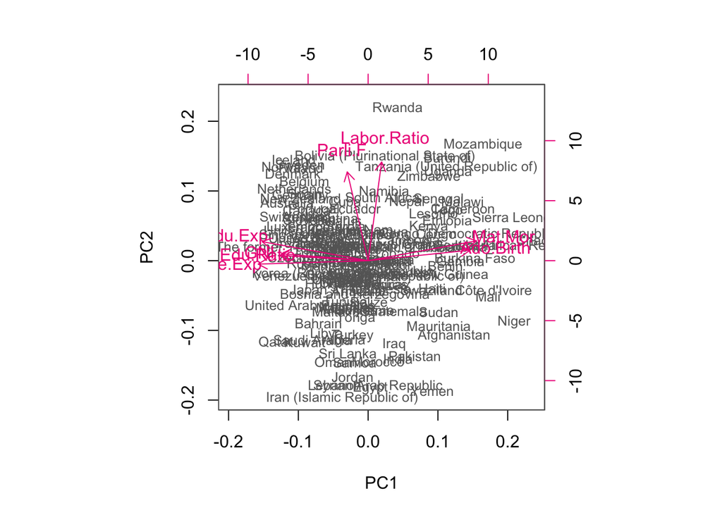

```r
# draw a biplot of the principal component representation and the original variables
biplot(pca_df, choices = 1:2, cex = c(0.8, 1), col = c("grey40", "deeppink2"))
```

Mat.mor and life.exp have the biggest correlation to the first principal component, explaning most in the variance. labor.ratio and parli.f give the largest correlation to the second principal component.

Next lets do the same with non-standardized data.

```r
pca_df_n <- prcomp(df)
pca_df_n
```

```
## Standard deviations (1, .., p=8):
## [1] 1.854416e+04 1.855219e+02 2.518701e+01 1.145441e+01 3.766241e+00
## [6] 1.565912e+00 1.912052e-01 1.591112e-01
##
## Rotation (n x k) = (8 x 8):
##                       PC1           PC2           PC3           PC4
## Edu.Ratio   -5.607472e-06  0.0006713951 -3.412027e-05 -2.736326e-04
## Labor.Ratio  2.331945e-07 -0.0002819357  5.302884e-04 -4.692578e-03
## Edu.Exp     -9.562910e-05  0.0075529759  1.427664e-02 -3.313505e-02
## Life.Exp    -2.815823e-04  0.0283150248  1.294971e-02 -6.752684e-02
## GNI         -9.999832e-01 -0.0057723054 -5.156742e-04  4.932889e-05
## Mat.Mor      5.655734e-03 -0.9916320120  1.260302e-01 -6.100534e-03
## Ado.Birth    1.233961e-03 -0.1255502723 -9.918113e-01  5.301595e-03
## Parli.F     -5.526460e-05  0.0032317269 -7.398331e-03 -9.971232e-01
##                       PC5           PC6           PC7           PC8
## Edu.Ratio   -0.0022935252  2.180183e-02  6.998623e-01  7.139410e-01
## Labor.Ratio  0.0022190154  3.264423e-02  7.132267e-01 -7.001533e-01
## Edu.Exp      0.1431180282  9.882477e-01 -3.826887e-02  7.776451e-03
## Life.Exp     0.9865644425 -1.453515e-01  5.380452e-03  2.281723e-03
## GNI         -0.0001135863 -2.711698e-05 -8.075191e-07 -1.176762e-06
## Mat.Mor      0.0266373214  1.695203e-03  1.355518e-04  8.371934e-04
## Ado.Birth    0.0188618600  1.273198e-02 -8.641234e-05 -1.707885e-04
## Parli.F     -0.0716401914 -2.309896e-02 -2.642548e-03  2.680113e-03
```

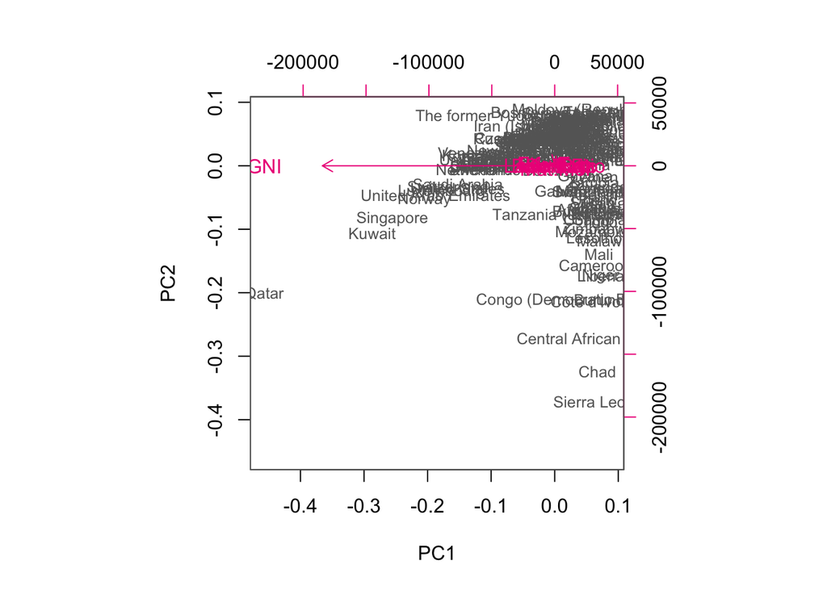

```r
biplot(pca_df_n, choices = 1:2, cex = c(0.8, 1), col = c("grey40", "deeppink2"))
```

```r
summary(df)
```

```
##    Edu.Ratio       Labor.Ratio        Edu.Exp         Life.Exp
##  Min.   :0.1717   Min.   :0.1857   Min.   : 5.40   Min.   :49.00
##  1st Qu.:0.7264   1st Qu.:0.5984   1st Qu.:11.25   1st Qu.:66.30
##  Median :0.9375   Median :0.7535   Median :13.50   Median :74.20
##  Mean   :0.8529   Mean   :0.7074   Mean   :13.18   Mean   :71.65
##  3rd Qu.:0.9968   3rd Qu.:0.8535   3rd Qu.:15.20   3rd Qu.:77.25
##  Max.   :1.4967   Max.   :1.0380   Max.   :20.20   Max.   :83.50
##       GNI            Mat.Mor         Ado.Birth         Parli.F
##  Min.   :   581   Min.   :   1.0   Min.   :  0.60   Min.   : 0.00
##  1st Qu.:  4198   1st Qu.:  11.5   1st Qu.: 12.65   1st Qu.:12.40
##  Median : 12040   Median :  49.0   Median : 33.60   Median :19.30
##  Mean   : 17628   Mean   : 149.1   Mean   : 47.16   Mean   :20.91
##  3rd Qu.: 24512   3rd Qu.: 190.0   3rd Qu.: 71.95   3rd Qu.:27.95
##  Max.   :123124   Max.   :1100.0   Max.   :204.80   Max.   :57.50
```

The pca and plots are very different. As the data is non-standardised, GNI which has the largest scale and therefore largest number for variance/standard deviation, and will have the highest contiribution to PCA.

The analysis suggests that as edu.ratio, edu.exp, life.exp, GNI, mat.mor and ado.birth have about similar correlations to component one, the tend also to correlate to each other as such that when one variable changes, so change the others, either to the same direction or to the other depending on +/-. The same counts for Parli.f and labor.ratio which had the highest correlations to component 2.

Next, let’s work with the tea data.

```r
#loading the data
tea <- read.csv("https://raw.githubusercontent.com/KimmoVehkalahti/Helsinki-Open-Data-Science/master/datasets/tea.csv", stringsAsFactors = TRUE)

library(FactoMineR)
library(ggplot2)

#exploring the data
str(tea)
```

```
## 'data.frame':    300 obs. of  36 variables:
##  $ breakfast       : Factor w/ 2 levels "breakfast","Not.breakfast": 1 1 2 2 1 2 1 2 1 1 ...
##  $ tea.time        : Factor w/ 2 levels "Not.tea time",..: 1 1 2 1 1 1 2 2 2 1 ...
##  $ evening         : Factor w/ 2 levels "evening","Not.evening": 2 2 1 2 1 2 2 1 2 1 ...
##  $ lunch           : Factor w/ 2 levels "lunch","Not.lunch": 2 2 2 2 2 2 2 2 2 2 ...
##  $ dinner          : Factor w/ 2 levels "dinner","Not.dinner": 2 2 1 1 2 1 2 2 2 2 ...
##  $ always          : Factor w/ 2 levels "always","Not.always": 2 2 2 2 1 2 2 2 2 2 ...
##  $ home            : Factor w/ 2 levels "home","Not.home": 1 1 1 1 1 1 1 1 1 1 ...
##  $ work            : Factor w/ 2 levels "Not.work","work": 1 1 2 1 1 1 1 1 1 1 ...
##  $ tearoom         : Factor w/ 2 levels "Not.tearoom",..: 1 1 1 1 1 1 1 1 1 2 ...
##  $ friends         : Factor w/ 2 levels "friends","Not.friends": 2 2 1 2 2 2 1 2 2 2 ...
##  $ resto           : Factor w/ 2 levels "Not.resto","resto": 1 1 2 1 1 1 1 1 1 1 ...
##  $ pub             : Factor w/ 2 levels "Not.pub","pub": 1 1 1 1 1 1 1 1 1 1 ...
##  $ Tea             : Factor w/ 3 levels "black","Earl Grey",..: 1 1 2 2 2 2 2 1 2 1 ...
##  $ How             : Factor w/ 4 levels "alone","lemon",..: 1 3 1 1 1 1 1 3 3 1 ...
```

[output cut: 22 more lines]

```r
dim(tea)
```

```
## [1] 300  36
```

```r
#taking the firs 10 variables
tea <- tea[,1:10]

#performing the analysis and giving the summary
mca <- MCA(tea, graph = FALSE)
summary(mca)
```

```
##
## Call:
## MCA(X = tea, graph = FALSE)
##
##
## Eigenvalues
##                        Dim.1   Dim.2   Dim.3   Dim.4   Dim.5   Dim.6   Dim.7
## Variance               0.179   0.129   0.115   0.107   0.104   0.090   0.079
## % of var.             17.939  12.871  11.481  10.654  10.406   8.985   7.917
## Cumulative % of var.  17.939  30.810  42.291  52.945  63.351  72.337  80.253
##                        Dim.8   Dim.9  Dim.10
## Variance               0.076   0.068   0.054
## % of var.              7.559   6.793   5.395
## Cumulative % of var.  87.812  94.605 100.000
##
## Individuals (the 10 first)
##                  Dim.1    ctr   cos2    Dim.2    ctr   cos2    Dim.3    ctr
## 1             | -0.543  0.549  0.474 | -0.462  0.552  0.342 | -0.007  0.000
## 2             | -0.543  0.549  0.474 | -0.462  0.552  0.342 | -0.007  0.000
## 3             | -0.068  0.009  0.002 |  0.542  0.761  0.141 | -0.139  0.056
## 4             | -1.037  1.998  0.558 |  0.264  0.180  0.036 | -0.018  0.001
## 5             | -0.235  0.103  0.061 | -0.011  0.000  0.000 |  0.124  0.044
## 6             | -1.037  1.998  0.558 |  0.264  0.180  0.036 | -0.018  0.001
## 7             |  0.024  0.001  0.001 | -0.404  0.422  0.374 | -0.185  0.099
## 8             | -0.193  0.069  0.054 |  0.058  0.009  0.005 | -0.382  0.423
## 9             | -0.258  0.124  0.117 | -0.624  1.007  0.680 | -0.130  0.049
## 10            | -0.048  0.004  0.002 | -0.153  0.061  0.020 | -0.176  0.090
##                 cos2
## 1              0.000 |
## 2              0.000 |
## 3              0.009 |
## 4              0.000 |
## 5              0.017 |
## 6              0.000 |
## 7              0.078 |
## 8              0.210 |
## 9              0.030 |
## 10             0.027 |
##
## Categories (the 10 first)
```

[output cut: 20 more lines]

```
## dinner          4.951 |  -0.090   0.050   0.001  -0.428 |
## Not.dinner     -4.951 |   0.007   0.004   0.001   0.428 |
##
## Categorical variables (eta2)
##                 Dim.1 Dim.2 Dim.3
## breakfast     | 0.040 0.547 0.001 |
## tea.time      | 0.358 0.083 0.043 |
## evening       | 0.103 0.210 0.188 |
## lunch         | 0.154 0.005 0.221 |
## dinner        | 0.186 0.082 0.001 |
## always        | 0.089 0.096 0.414 |
## home          | 0.008 0.114 0.005 |
## work          | 0.215 0.006 0.251 |
## tearoom       | 0.315 0.003 0.018 |
## friends       | 0.325 0.141 0.008 |
```

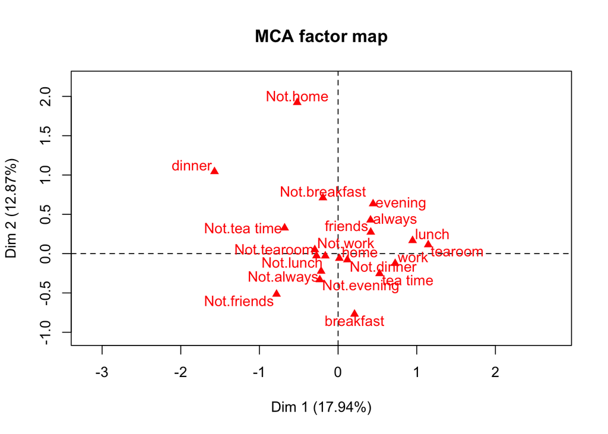

```r
plot(mca, invisible=c("ind"), graph.type = "classic")
```

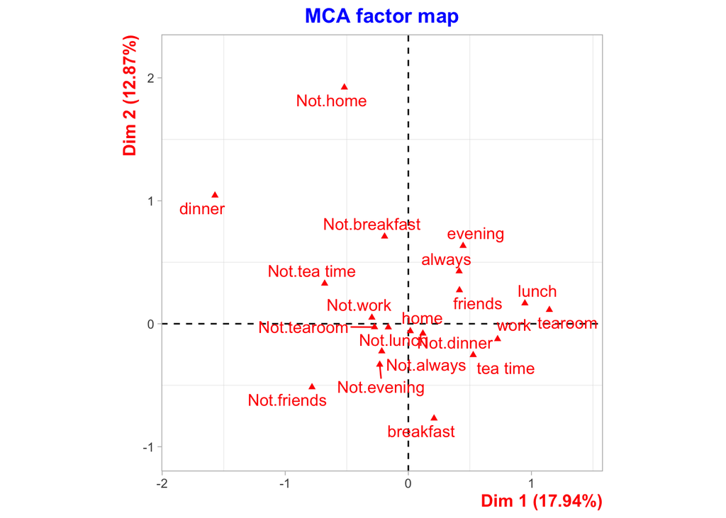

```r
plot(mca, invisible=c("ind"), graph.type = c("ggplot")) + theme(panel.grid.major = element_blank(),
   plot.title=element_text(size=14, color="blue"),
   axis.title = element_text(size=12, color="red"))
```

Tea-time, work, tearoom, and friends are strongly correlated to the firs dimension and as such tend to change together. Breakfast, evening are strongly correlated to the second dimension. lunch, always and work are strongly correlated to the third dimension.